# Welcome to the *Ecological Data Management and Analysis* Web page!

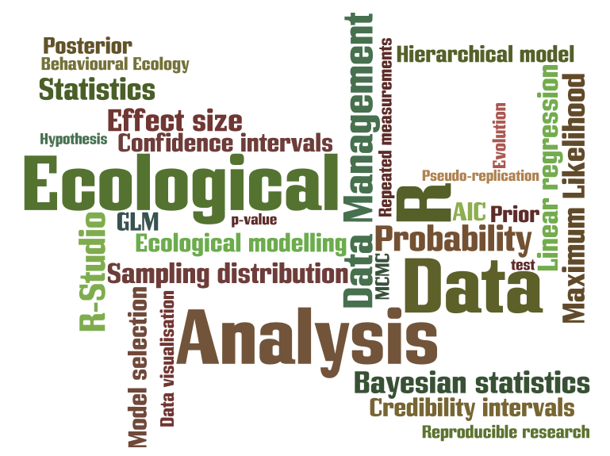

This course intends to gently introduce data management and modern analysis techniques and concepts to students in the Natural Sciences. The course is taught in a traditional way at the University of Torino (see the official course page [here](http://naturali.campusnet.unito.it/do/corsi.pl/Show?_id=af34)) but all course materials, including videos of the lessons, will be accessible online under a Creative Commons licence, both here as well as on the [Moodle platform](http://naturali.i-learn.unito.it/course/view.php?id=74) of the University of Torino (If you do not have a valid University of Torino account, you can access as Guest).

While we will mostly use examples in the fields of Evolutionary and Behavioural Ecology, the course can be followed by students from other scientific domains. Classical, maximum- likelihood and Bayesian approaches will be introduced. The course will not be heavy on mathematics and statistical theory, trying instead to explain the concepts behind modern statistical tools mostly in a graphical and engaging way using interesting ecological examples. The teaching philosophy will be problem-solving oriented, and therefore students will have the chance to practically apply all the acquired concepts and methods to real data using the open-source statistical language *R* and the friendly *RStudio* interface. An introductory *R-Lab* will provide the necessary know-how in the use of these powerful tools. Specifically developed tutorials and interactive exercises will assist the student during the whole learning process.

This website and all course materials are hosted on github [here](https://github.com/achazhardenberg/ecostats.co). Please feel free to fork the repository and use what you need for your own lessons!

Enjoy!

*Achaz von Hardenberg*  
*Course Instructor*